# Análisis Exploratorio de datos en Europa: Regresión Logística

Alicia Perdices Guerra

11 de junio, 2021

- **1.ANÁLISIS EXPLORATORIO.MODELOS DE REGRESION.**
  - 1.1 **ANÁLISIS EXPLORATORIO.FILTRADO DE LA INFORMACIÓN PARA ITALIA, ALEMANIA, REINO UNIDO,FRANCIA Y ESPAÑA**
    - 1.1.1 Se filtra informacion (De todas los archivos disponibles). Se genera variable con la información necesaria en relación con Gasto, Recursos, Actividades Sanitarias, Cuidados Domiciliarios, Estado de Salud, Prevención y Mortalidad.
    - 1.1.2 Modelo de regresión lineal que explique la mortalidad (Mortalidad Prevenible, Mortalidad Tratable) en función del número de Médicos de Atención Primaria, y de Recursos como disposición de Unidades de Resonancia Magnética y Scanners para diagnóstico, Detección de Cancer de Mama, Cervix Uterino y Vacunación.
    - 1.1.3 Modelo de regresión logística que estime la probabilidad de una variable cualitativa (Se transforma Mortalidad_Tratable y Prevenible en variable cualitativa, con valores de 0 si el país no supera la media muestral para esa variable y 1 en caso contrario), en función de variables cuantitativas (Médicos de Atención Primaria, de Recursos como disposición de Unidades de Resonancia Magnética y Scanners para diagnóstico, y Detección de Cancer de Mama, Cervix Uterino y Vacunación)
    - 1.1.4. Predicciones.

#### **1.1 ANÁLISIS EXPLORATORIO.FILTRADO DE LA INFORMACIÓN POR PAISES.**

Se procede en primer lugar a cargar todos los archivos para poder realizar el análisis.

```r
camas_disponibles<-read.csv("C:/temp/Camas_Disponibles_Analisis.csv",sep= ",")
cuidados<-read.csv("C:/temp/Cuidados_Domiciliarios_Analisis.csv",sep= ",")
estado<-read.csv("C:/temp/Estado_Salud_Analisis.csv",sep= ",")
financiacion<-read.csv("C:/temp/Financiacion.csv",sep= ",")
gasto<-read.csv("C:/temp/GastoSanitario_Analisis.csv",sep= ",")
medicos<-read.csv("C:/temp/Medicos_Analisis.csv",sep= ",")
mortalidad<-read.csv("C:/temp/Mortalidad_Analisis.csv",sep= ",")
ocupacion_cama<-read.csv("C:/temp/Ocupacion_Cama_Analisis.csv",sep= ",")
personalSanitarioNoMedicos<-read.csv("C:/temp/PersonalSanitarioNoMedicos_Analisis.csv",sep= ",")
prevencion<-read.csv("C:/temp/Prevencion_Analisis.csv",sep= ",")
ratio_Pacientes_Dialisis<-read.csv("C:/temp/Ratio_Pacientes_Dialisis_Analisis.csv",sep= ",")
ratio_Pacientes_Trasplantados<-read.csv("C:/temp/Ratio_Pacientes_Trasplantados_Analisis.csv",sep= ",")
recursos_tecnologicos<-read.csv("C:/temp/Recursos_Tecnologicos_Analisis.csv",sep= ",")
tecnologia_medica<-read.csv("C:/temp/Tecnologia_Medica_Analisis.csv",sep= ",")
```

**1.1.1 Filtrado de la información para los Paises foco de estudio**

Estudio de regresion de la mortalidad tratable y prevenible en Europa en relación con del número de Médicos de Atención Primaria, y de Recursos como disposición de Unidades de Resonancia Magnética y Scanners para diagnóstico.

```r
#Se estudia la información para los distintos paises en el rango de años 2011-2017,
#ya que no existe información de todas las variables estudiadas para todos los años(2009-2019).
 #solo para los años 2011-2017
financiacion<-filter(financiacion,
                     (TIME==2011)|
                     (TIME==2012)|
                     (TIME==2013)|
                     (TIME==2014)|
                     (TIME==2015)|
                     (TIME==2016)|
                     (TIME==2017))
financiacion<-filter(financiacion,
                     (GEO=="Spain")|
                      GEO=="Italy"|
                      GEO=="United Kingdom"|
                      GEO=="France"|
                      GEO=="Germany (until 1990 former territory of the FRG)")
nrow(financiacion)
```

```
## [1] 35
```

```r
head(financiacion)
```

```
##   TIME                                              GEO             ICHA11_HF
## 1 2011 Germany (until 1990 former territory of the FRG) All financing schemes
## 2 2011                                            Spain All financing schemes
## 3 2011                                           France All financing schemes
## 4 2011                                            Italy All financing schemes
## 5 2011                                   United Kingdom All financing schemes
## 6 2012 Germany (until 1990 former territory of the FRG) All financing schemes
##       Value Value_imp
## 1 290266.00     FALSE
## 2  97532.09     FALSE
## 3 230575.03     FALSE
## 4 142676.00      TRUE
## 5 229998.79      TRUE
## 6 297784.00     FALSE
```

```r
camas_disponibles<-filter(camas_disponibles,
                     (TIME==2011)|
                     (TIME==2012)|
                     (TIME==2013)|
                     (TIME==2014)|
                     (TIME==2015)|
                     (TIME==2016)|
                     (TIME==2017))
camas_disponibles<-filter(camas_disponibles,
                     (GEO=="Spain")|
                      GEO=="Italy"|
                      GEO=="United Kingdom"|
                      GEO=="France"|
                      GEO=="Germany (until 1990 former territory of the FRG)")


nrow(camas_disponibles)
```

```
## [1] 35
```

```r
head(camas_disponibles)
```

```
##   TIME                                              GEO   UNIT
## 1 2011 Germany (until 1990 former territory of the FRG) Number
## 2 2011                                            Spain Number
## 3 2011                                           France Number
## 4 2011                                            Italy Number
## 5 2011                                   United Kingdom Number
## 6 2012 Germany (until 1990 former territory of the FRG) Number
##                             FACILITY  Value Value_imp
## 1 Available beds in hospitals (HP.1) 672573     FALSE
## 2 Available beds in hospitals (HP.1) 142394     FALSE
## 3 Available beds in hospitals (HP.1) 414204     FALSE
## 4 Available beds in hospitals (HP.1) 208854     FALSE
## 5 Available beds in hospitals (HP.1) 181972     FALSE
## 6 Available beds in hospitals (HP.1) 670443     FALSE
```

```r
estado<-filter(estado,
                     (TIME==2011)|
                     (TIME==2012)|
                     (TIME==2013)|
                     (TIME==2014)|
                     (TIME==2015)|
                     (TIME==2016)|
                     (TIME==2017))
estado<-filter(estado,
                     Pais=="Spain"|
                     Pais=="Italy"|
                     Pais=="United Kingdom"|
                     Pais=="France"|
                     Pais=="Germany (until 1990 former territory of the FRG)")

nrow(estado)
```

```
## [1] 35
```

```r
head(estado)
```

```
##   TIME                                             Pais Estado_males
## 1 2011 Germany (until 1990 former territory of the FRG)         57.8
## 2 2011                                            Spain         65.4
## 3 2011                                           France         62.7
## 4 2011                                            Italy         63.6
## 5 2011                                   United Kingdom         65.2
## 6 2012 Germany (until 1990 former territory of the FRG)         57.3
##   Estado_females
## 1           58.6
## 2           65.6
## 3           63.6
## 4           62.5
## 5           65.2
## 6           57.9
```

```r
gasto<-filter(gasto,
                     (TIME==2011)|
                     (TIME==2012)|
                     (TIME==2013)|
                     (TIME==2014)|
                     (TIME==2015)|
                     (TIME==2016)|
                     (TIME==2017))
gasto<-filter(gasto,
                     Pais=="Spain"|
                     Pais=="Italy"|
                     Pais=="United Kingdom"|
                     Pais=="France"|
                     Pais=="Germany (until 1990 former territory of the FRG)")

nrow(gasto)
```

```
## [1] 35
```

```r
head(gasto)
```

```
##   TIME                                             Pais
## 1 2011 Germany (until 1990 former territory of the FRG)
## 2 2011                                            Spain
## 3 2011                                           France
## 4 2011                                            Italy
## 5 2011                                   United Kingdom
## 6 2012 Germany (until 1990 former territory of the FRG)
##   Gasto_Cuidado_Rehabilitacion Gasto_Cuidado_Rehabilitacion_Ingresados
## 1                    150588.00                                80315.00
## 2                     55849.51                                23772.32
## 3                    121151.32                                64954.38
## 4                     79760.00                                41034.00
## 5                    126551.13                                53271.07
## 6                    154062.00                                82352.00
##   Gasto_Hospitales Gasto_Hospitales_Mentales Gasto_Hospitales_Especiales
## 1         84816.00                   1613.05                     8364.00
## 2         41164.82                    774.08                     2172.17
## 3         87269.89                  13272.43                      331.86
## 4         65633.00                    981.36                       66.39
## 5         93210.11                    981.36                       66.39
## 6         86930.00                   1039.49                     8686.00
```

```r
medicos<-filter(medicos,
                     (TIME==2011)|
                     (TIME==2012)|
                     (TIME==2013)|
                     (TIME==2014)|
                     (TIME==2015)|
                     (TIME==2016)|
                     (TIME==2017))
medicos<-filter(medicos,
                     Pais=="Spain"|
                     Pais=="Italy"|
                     Pais=="United Kingdom"|
                     Pais=="France"|
                     Pais=="Germany (until 1990 former territory of the FRG)")

nrow(medicos)
```

```
## [1] 35
```

```r
head(medicos)
```

```
##   TIME                                             Pais
## 1 2011 Germany (until 1990 former territory of the FRG)
## 2 2011                                            Spain
## 3 2011                                           France
## 4 2011                                            Italy
## 5 2011                                   United Kingdom
## 6 2012 Germany (until 1990 former territory of the FRG)
##   Generalist_medical_practitioners Specialist_medical_practitioners
## 1                            75252                           235971
## 2                            34722                           108759
## 3                            93140                           106780
## 4                            53856                           177625
## 5                            49838                           120479
## 6                            75390                           242000
##   General_paediatricians AGE_Total AGE_Less_35 AGE_35_44 AGE_45_54 AGE_55_64
## 1                  12854    311223       57748     36100     91591    114365
## 2                  12037    179267       43700     44867     49333     34933
## 3                   7287    199920       17865     37929     61853     69758
## 4                  17475    379930       50260     54414    104373    123815
## 5                   9170     30327        3458      8143      9135      7464
## 6                  13047    317390       58379     37274     88334    120468
```

```r
prevencion<-filter(prevencion,
                     (TIME==2011)|
                     (TIME==2012)|
                     (TIME==2013)|
                     (TIME==2014)|
                     (TIME==2015)|
                     (TIME==2016)|
                     (TIME==2017))
prevencion<-filter(prevencion,
                     Pais=="Spain"|
                     Pais=="Italy"|
                     Pais=="United Kingdom"|
                     Pais=="France"|
                     Pais=="Germany (until 1990 former territory of the FRG)")

nrow(prevencion)
```

```
## [1] 35
```

```r
head(prevencion)
```

```
##   TIME                                             Pais Deteccion_cancer_mama
## 1 2011 Germany (until 1990 former territory of the FRG)                  71.3
## 2 2011                                            Spain                  77.1
## 3 2011                                           France                  75.4
## 4 2011                                            Italy                  70.1
## 5 2011                                   United Kingdom                  70.1
## 6 2012 Germany (until 1990 former territory of the FRG)                  71.3
##   Deteccion_cancer_cervix_uterino Vacunacion
## 1                           76.90       56.1
## 2                           67.70       57.7
## 3                           73.59       55.2
## 4                           76.90       62.4
## 5                           67.70       74.0
## 6                           73.59       58.6
```

```r
recursos_tecnologicos<-filter(recursos_tecnologicos,
                     (TIME==2011)|
                     (TIME==2012)|
                     (TIME==2013)|
                     (TIME==2014)|
                     (TIME==2015)|
                     (TIME==2016)|
                     (TIME==2017))
recursos_tecnologicos<-filter(recursos_tecnologicos,
                     Pais=="Spain"|
                     Pais=="Italy"|
                     Pais=="United Kingdom"|
                     Pais=="France"|
                     Pais=="Germany (until 1990 former territory of the FRG)")

nrow(recursos_tecnologicos)
```

```
## [1] 35
```

```r
head(recursos_tecnologicos)
```

```
##   TIME                                             Pais
## 1 2011 Germany (until 1990 former territory of the FRG)
## 2 2011                                            Spain
## 3 2011                                           France
## 4 2011                                            Italy
## 5 2011                                   United Kingdom
## 6 2012 Germany (until 1990 former territory of the FRG)
##   Operation_theatres_in_hospital Surgical_day_care_places
## 1                           1241                       53
## 2                           4202                     2838
## 3                          11337                    14110
## 4                           6092                     8013
## 5                           3636                     2177
## 6                           1258                       73
##   Psychiatric_day_care_place Oncological_day_care_place
## 1                      15457                        983
## 2                       3366                       6957
## 3                      28424                       6052
## 4                        631                       3056
## 5                       3366                       1460
## 6                      16773                       1047
##   Geriatric_day_care_places
## 1                      1949
## 2                      2297
## 3                       628
## 4                       206
## 5                      1949
## 6                      2013
```

```r
tecnologia_medica<-filter(tecnologia_medica,
                     (TIME==2011)|
                     (TIME==2012)|
                     (TIME==2013)|
                     (TIME==2014)|
                     (TIME==2015)|
                     (TIME==2016)|
                     (TIME==2017))
tecnologia_medica<-filter(tecnologia_medica,
                     Pais=="Spain"|
                     Pais=="Italy"|
                     Pais=="United Kingdom"|
                     Pais=="France"|
                     Pais=="Germany (until 1990 former territory of the FRG)")
nrow(tecnologia_medica)
```

```
## [1] 35
```

```r
head(tecnologia_medica)
```

```
##   TIME                                             Pais
## 1 2011 Germany (until 1990 former territory of the FRG)
## 2 2011                                            Spain
## 3 2011                                           France
## 4 2011                                            Italy
## 5 2011                                   United Kingdom
## 6 2012 Germany (until 1990 former territory of the FRG)
##   Computed_Tomography_Scanners Gamma_cameras Lithotriptors
## 1                      2688.00            97            84
## 2                       778.00           286            81
## 3                       816.00           345            34
## 4                      1937.00           680            34
## 5                       536.29            97            34
## 6                      2735.00           119            63
##   Magnetic_Resonance_Imaging_Units Angiography_units
## 1                          2317.00                76
## 2                           643.00               249
## 3                           489.00                70
## 4                          1435.00               759
## 5                           440.52                70
## 6                          2305.00                81
```

```r
mortalidad<-filter(mortalidad,
                     Pais=="Spain"|
                     Pais=="Italy"|
                     Pais=="United Kingdom"|
                     Pais=="France"|
                     Pais=="Germany (until 1990 former territory of the FRG)")

nrow(mortalidad)
```

```
## [1] 35
```

Una vez analizado la información sobre las causas de Mortalidad, Resursos, Prevención, Actividades, Estado de Salud, Cuidados Domiciliarios y Gastos Sanitarios de forma individual por años y países, se procede a establecer relaciones entre las distintas variables por países (se ha escogido los 5 países con mayor gasto y recursos sanitarios para hacer el estuido de forma conjunta. Se procede a estimar un modelo de regresión logística que explique unas variables en función de otras para después poder hacer predicciones sobre hipótesis de datos nuevos, por ejemplo si existe relación entre la mortalidad prevenible de un país y el número de médicos disponibles y qué mortalidad cabría esperar si aumentamos o disminuimos estos recursos.

- **1.1.2 Modelo de regresión lineal/logística que explique la mortalidad (Mortalidad Prevenible, Mortalidad Tratable) en función del número de Médicos de Atención Primaria ,de Recursos como disposición de Unidades de Resonancia Magnética y Scanners para diagnóstico, y actividades de Diagnóstico de Cancer_mama , Cáncer de Cervix Uterino, y Vacunación**

Se analiza en primer lugar si tiene sentido estimar un modelo de regresión simple entre variables y qué variables serían las adecuadas.

- La relación entre el predictor y la variable respuesta ha de ser lineal. Se puede comprobar con diagrama de dispersión y graficando los residuos.
- Los residuos deben distribuirse normalmente en torno a 0. Se puede comprobar con la distribución de quantiles (normal Q-Q plot) o test de hipótesis de normalidad.
- La variabilidad de los residuos debe ser constante (homocedasticidad): la variabilidad de los datos entorno a la recta de regresión ha de ser aproximadamente constante. Se comprueba graficando los residuos o mediante el test de Breusch-Pagan.

```r
head(mortalidad)
```

```
##   TIME                                             Pais Mortalidad_Prevenible
## 1 2011 Germany (until 1990 former territory of the FRG)              127461.0
## 2 2011                                            Spain               47858.0
## 3 2011                                           France               78950.5
## 4 2011                                            Italy               68165.5
## 5 2011                                   United Kingdom               82226.0
## 6 2012 Germany (until 1990 former territory of the FRG)              125457.5
##   Mortalidad_Tratable Mortalidad_A00_B99 Mortalidad_G00_R50
## 1             74029.0               7411              15593
## 2             27292.0               2946              11834
## 3             35604.5               5094              11842
## 4             41124.5               5423              10691
## 5             48861.0               2555              17160
## 6             72005.5               8232              15598
##   Mortalidad_pneumonia Other_sepsis
## 1                18020         7411
## 2                 7819         2946
## 3                 9971         5094
## 4                 8211         5423
## 5                27968         2555
## 6                17776         8232
```

```r
europa_regresion1<-
  select(mortalidad,TIME,Pais,Mortalidad_Prevenible,Mortalidad_Tratable)
head(europa_regresion1)
```

```
##   TIME                                             Pais Mortalidad_Prevenible
## 1 2011 Germany (until 1990 former territory of the FRG)              127461.0
## 2 2011                                            Spain               47858.0
## 3 2011                                           France               78950.5
## 4 2011                                            Italy               68165.5
## 5 2011                                   United Kingdom               82226.0
## 6 2012 Germany (until 1990 former territory of the FRG)              125457.5
##   Mortalidad_Tratable
## 1             74029.0
## 2             27292.0
## 3             35604.5
## 4             41124.5
## 5             48861.0
## 6             72005.5
```

```r
nrow(europa_regresion1)
```

```
## [1] 35
```

```r
europa_regresion2<-
  select(tecnologia_medica,Computed_Tomography_Scanners,Magnetic_Resonance_Imaging_Units)
head(europa_regresion2)
```

```
##   Computed_Tomography_Scanners Magnetic_Resonance_Imaging_Units
## 1                      2688.00                          2317.00
## 2                       778.00                           643.00
## 3                       816.00                           489.00
## 4                      1937.00                          1435.00
## 5                       536.29                           440.52
## 6                      2735.00                          2305.00
```

```r
nrow(europa_regresion2)
```

```
## [1] 35
```

```r
europa_regresion3<-
  select(medicos,Generalist_medical_practitioners)
head(europa_regresion3)
```

```
##   Generalist_medical_practitioners
## 1                            75252
## 2                            34722
## 3                            93140
## 4                            53856
## 5                            49838
## 6                            75390
```

```r
nrow(europa_regresion3)
```

```
## [1] 35
```

```r
europa_regresion4<-
  select(prevencion,Deteccion_cancer_mama,Deteccion_cancer_cervix_uterino,Vacunacion)
europa_regresion<-data.frame(europa_regresion1,europa_regresion2,europa_regresion3,europa_regresion4)
head(europa_regresion)
```

```
##   TIME                                             Pais Mortalidad_Prevenible
## 1 2011 Germany (until 1990 former territory of the FRG)              127461.0
## 2 2011                                            Spain               47858.0
## 3 2011                                           France               78950.5
## 4 2011                                            Italy               68165.5
## 5 2011                                   United Kingdom               82226.0
## 6 2012 Germany (until 1990 former territory of the FRG)              125457.5
##   Mortalidad_Tratable Computed_Tomography_Scanners
## 1             74029.0                      2688.00
## 2             27292.0                       778.00
## 3             35604.5                       816.00
## 4             41124.5                      1937.00
## 5             48861.0                       536.29
## 6             72005.5                      2735.00
##   Magnetic_Resonance_Imaging_Units Generalist_medical_practitioners
## 1                          2317.00                            75252
## 2                           643.00                            34722
## 3                           489.00                            93140
## 4                          1435.00                            53856
## 5                           440.52                            49838
## 6                          2305.00                            75390
##   Deteccion_cancer_mama Deteccion_cancer_cervix_uterino Vacunacion
## 1                  71.3                           76.90       56.1
## 2                  77.1                           67.70       57.7
## 3                  75.4                           73.59       55.2
## 4                  70.1                           76.90       62.4
## 5                  70.1                           67.70       74.0
## 6                  71.3                           73.59       58.6
```

- Se comprueba si el predictor y la variable respuesta tienen una relación lineal mediante un diagrama de dispersión.

**Mortalidad_Prevenible,Generalist_medical_practitioners**

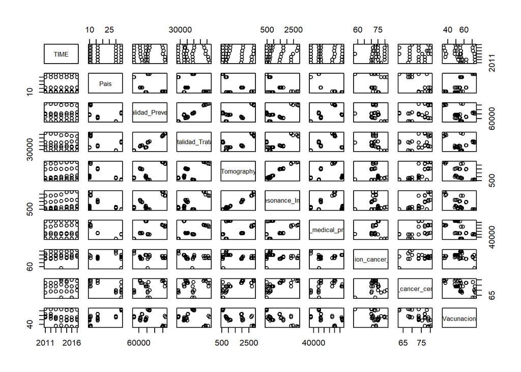

```r
#Gráficos de dispersión del conjunto de variables
pairs(europa_regresion)
```

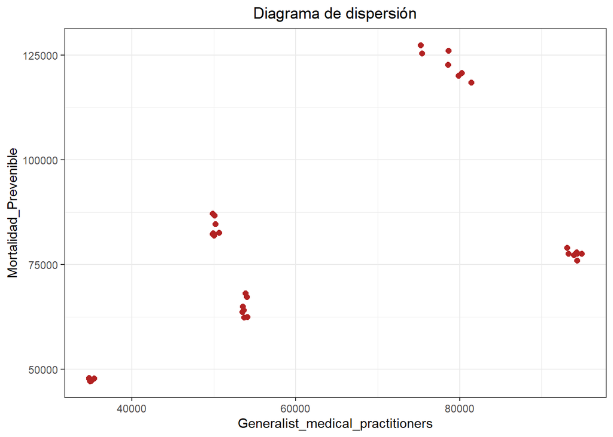

```r
ggplot(data = europa_regresion,
       mapping = aes(x =Generalist_medical_practitioners , y = Mortalidad_Prevenible)) +
geom_point(color = "firebrick", size = 2) +
labs(title = "Diagrama de dispersión",
     x = "Generalist_medical_practitioners", y = "Mortalidad_Prevenible") +
theme_bw() +
theme(plot.title = element_text(hjust = 0.5))
```

No se observa una dependencia lineal, por lo que el modelo de regresión lineal no estaría justificado.

**Mortalidad_Tratable,Generalist_medical_practitioners**

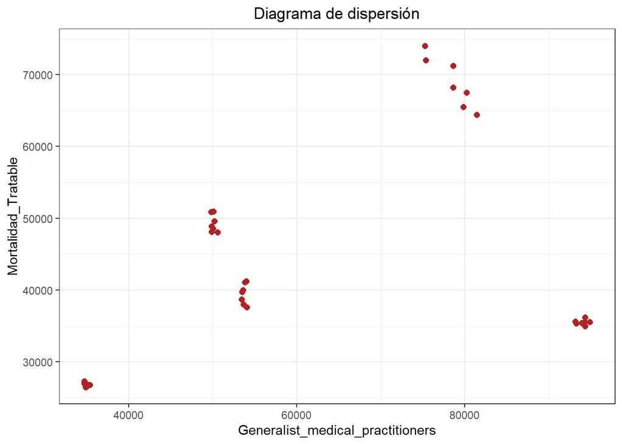

```r
#Gráficos de dispersión del conjunto de variables
ggplot(data = europa_regresion,
       mapping = aes(x =Generalist_medical_practitioners , y = Mortalidad_Tratable)) +
geom_point(color = "firebrick", size = 2) +
labs(title = "Diagrama de dispersión",
     x = "Generalist_medical_practitioners", y = "Mortalidad_Tratable") +
theme_bw() +
theme(plot.title = element_text(hjust = 0.5))
```

No se observa una dependencia lineal, por lo que el modelo de regresión lineal no estaría justificado.

**Mortalidad_Tratable,Computed_Tomography_Scanners**

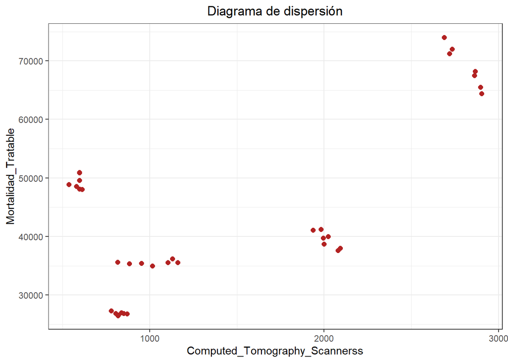

```r
ggplot(data = europa_regresion,
       mapping = aes(x =Computed_Tomography_Scanners , y = Mortalidad_Tratable)) +
geom_point(color = "firebrick", size = 2) +
labs(title = "Diagrama de dispersión",
     x = "Computed_Tomography_Scannerss", y = "Mortalidad_Tratable") +
theme_bw() +
theme(plot.title = element_text(hjust = 0.5))
```

No se observa una dependencia lineal, por lo que el modelo de regresión lineal no estaría justificado.

**Mortalidad_Tratable,Magnetic_Resonance_Imaging_Units**

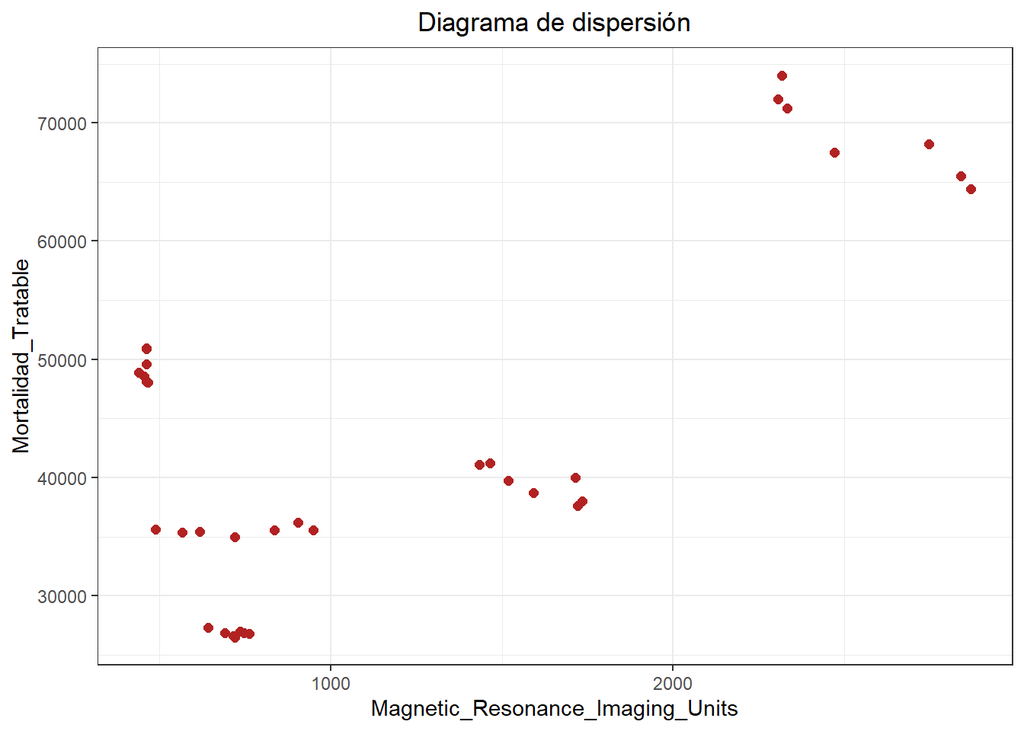

```r
ggplot(data = europa_regresion,
       mapping = aes(x =Magnetic_Resonance_Imaging_Units, y = Mortalidad_Tratable)) +
geom_point(color = "firebrick", size = 2) +
labs(title = "Diagrama de dispersión",
     x = "Magnetic_Resonance_Imaging_Units", y = "Mortalidad_Tratable") +
theme_bw() +
theme(plot.title = element_text(hjust = 0.5))
```

No se observa una dependencia lineal, por lo que el modelo de regresión lineal no estaría justificado.

**Mortalidad_Prevenible,Deteccion_cancer_mama**

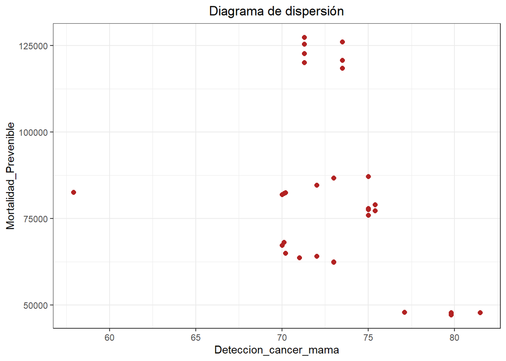

```r
ggplot(data = europa_regresion,
       mapping = aes(x =Deteccion_cancer_mama, y = Mortalidad_Prevenible)) +
geom_point(color = "firebrick", size = 2) +
labs(title = "Diagrama de dispersión",
     x = "Deteccion_cancer_mama", y = "Mortalidad_Prevenible") +
theme_bw() +
theme(plot.title = element_text(hjust = 0.5))
```

No se observa una dependencia lineal, por lo que el modelo de regresión lineal no estaría justificado.

**Mortalidad_Prevenible,Deteccion_cancer_cervix_uterino**

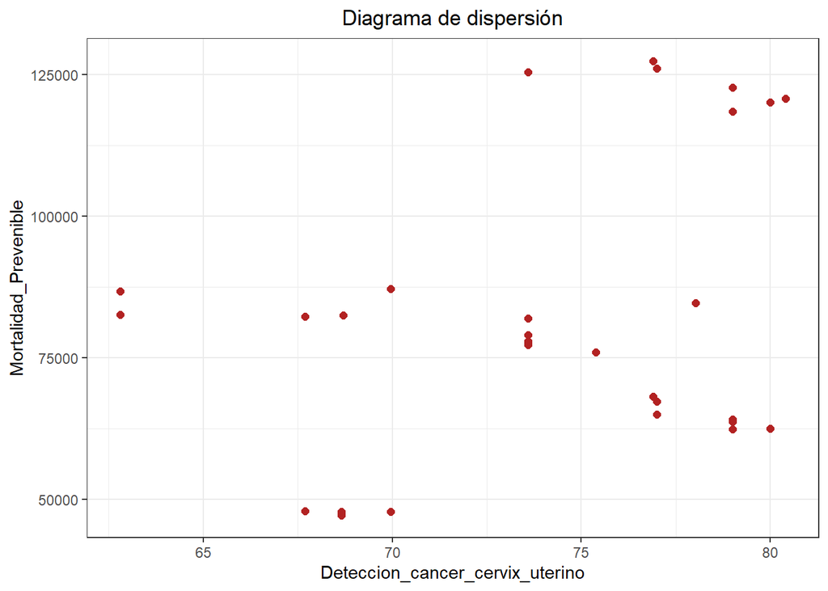

```r
ggplot(data = europa_regresion,
       mapping = aes(x =Deteccion_cancer_cervix_uterino, y = Mortalidad_Prevenible)) +
geom_point(color = "firebrick", size = 2) +
labs(title = "Diagrama de dispersión",
     x = "Deteccion_cancer_cervix_uterino", y = "Mortalidad_Prevenible") +
theme_bw() +
theme(plot.title = element_text(hjust = 0.5))
```

No se observa una dependencia lineal, por lo que el modelo de regresión lineal no estaría justificado.

**Mortalidad_Prevenible,Vacunacion**

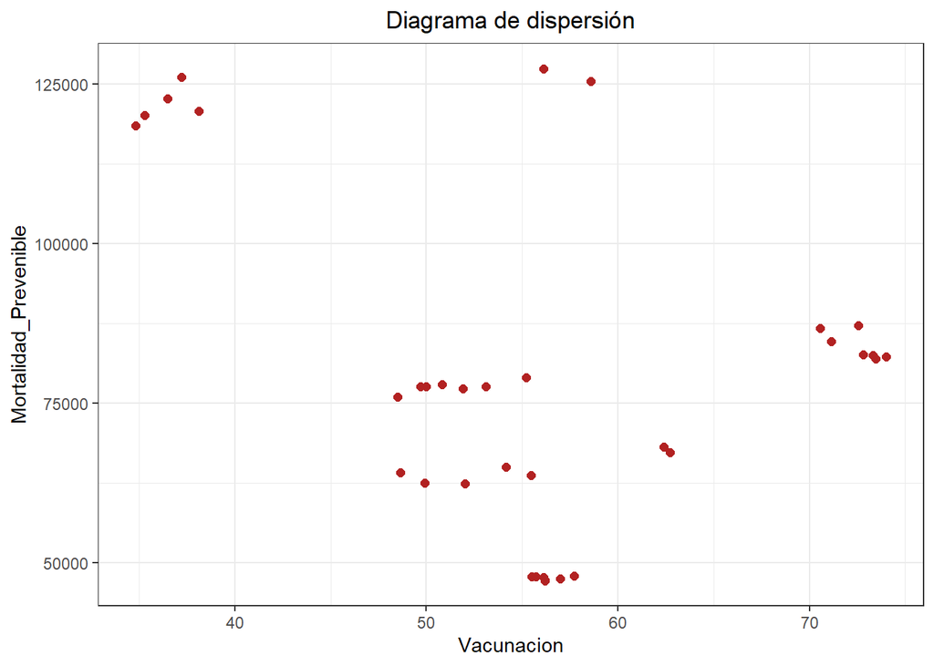

```r
ggplot(data = europa_regresion,
       mapping = aes(x =Vacunacion, y = Mortalidad_Prevenible)) +
geom_point(color = "firebrick", size = 2) +
labs(title = "Diagrama de dispersión",
     x = "Vacunacion", y = "Mortalidad_Prevenible") +
theme_bw() +
theme(plot.title = element_text(hjust = 0.5))
```

No se observa una dependencia lineal, por lo que el modelo de regresión lineal no estaría justificado.

No tiene sentido pensar en un modelo de regresión lineal para las variables e información disponible para el estuido.

- **1.1.3 Modelos de regresión logística**

Modelo de regresión logística que estime la probabilidad de una variable cualitativa (Se transforma Mortalidad_Tratable y Prevenible en variable cualitativa, con valores de 0 si el país no supera la media muestral para esa variable y 1 en caso contrario), en función de variables cuantitativas (Médicos de Atención Primaria, y de Recursos como disposición de Unidades de Resonancia Magnética y Scanners para diagnóstico)

- se transforma la variable **Mortalidad_Tratable** y **Mortalidad_Prevenible** en cualitativas (con valores 0 y 1).

```r
#Media muestral de la variable Mortalidad_Tratable en todos los paises Europeos.(variable mortalidad)
mean_mt<-mean(mortalidad$Mortalidad_Tratable)

#Media muestral de la variable Mortalidad_Prevenible en todos los paises Europeos.(variable mortalidad)
mean_mp<-mean(mortalidad$Mortalidad_Prevenible)

#Se transforma Mortalidad_Tratable en variable cualitativa.
europa_regresion$Mortalidad_Tratable_01<-ifelse(europa_regresion$Mortalidad_Tratable<mean_mt,0,1)

#Se transforma Mortalidad_Prevenible en variable cualitativa.
europa_regresion$Mortalidad_Prevenible_01<-ifelse(europa_regresion$Mortalidad_Prevenible<mean_mp,0,1)
tail(europa_regresion)
```

```
##    TIME                                             Pais Mortalidad_Prevenible
## 30 2016                                   United Kingdom               86777.5
## 31 2017 Germany (until 1990 former territory of the FRG)              118506.5
## 32 2017                                            Spain               47815.5
## 33 2017                                           France               77585.5
## 34 2017                                            Italy               62353.5
## 35 2017                                   United Kingdom               87159.0
##    Mortalidad_Tratable Computed_Tomography_Scanners
## 30             50951.5                       596.61
## 31             64417.5                      2904.00
## 32             26835.5                       869.00
## 33             35583.0                      1161.00
## 34             38040.5                      2093.00
## 35             50880.0                       596.61
##    Magnetic_Resonance_Imaging_Units Generalist_medical_practitioners
```

[output cut: 20 more lines]

```r
table(europa_regresion$Mortalidad_Tratable_01)
```

```
##
##  0  1
## 21 14
```

```r
table(europa_regresion$Mortalidad_Prevenible_01)
```

```
##
##  0  1
## 21 14
```

Se ajusta un modelo de regresión logística para predecir la probabilidad de tener una Mortalidad Tratable que supere la media en función de las variables Médicos de Atención Primaria, y de Recursos como disposición de Unidades de Resonancia Magnética y Scanners para diagnóstico.

```r
modelo.log.1<-
  glm(Mortalidad_Tratable_01~Generalist_medical_practitioners, family = binomial(), data= europa_regresion)
summary(modelo.log.1)
```

```
##
## Call:
## glm(formula = Mortalidad_Tratable_01 ~ Generalist_medical_practitioners,
##     family = binomial(), data = europa_regresion)
##
## Deviance Residuals:
##     Min       1Q   Median       3Q      Max
## -1.1087  -0.9853  -0.9306   1.3061   1.3962
##
## Coefficients:
##                                    Estimate Std. Error z value Pr(>|z|)
## (Intercept)                      -8.737e-01  1.082e+00  -0.808    0.419
## Generalist_medical_practitioners  7.483e-06  1.629e-05   0.459    0.646
##
## (Dispersion parameter for binomial family taken to be 1)
##
##     Null deviance: 47.111  on 34  degrees of freedom
## Residual deviance: 46.899  on 33  degrees of freedom
## AIC: 50.899
##
## Number of Fisher Scoring iterations: 4
```

```r
modelo.log.2<-
  glm(Mortalidad_Prevenible_01~Generalist_medical_practitioners, family = binomial(), data= europa_regresion)
summary(modelo.log.2)
```

```
##
## Call:
## glm(formula = Mortalidad_Prevenible_01 ~ Generalist_medical_practitioners,
##     family = binomial(), data = europa_regresion)
##
## Deviance Residuals:
##     Min       1Q   Median       3Q      Max
## -1.1087  -0.9853  -0.9306   1.3061   1.3962
##
## Coefficients:
##                                    Estimate Std. Error z value Pr(>|z|)
## (Intercept)                      -8.737e-01  1.082e+00  -0.808    0.419
## Generalist_medical_practitioners  7.483e-06  1.629e-05   0.459    0.646
##
## (Dispersion parameter for binomial family taken to be 1)
##
##     Null deviance: 47.111  on 34  degrees of freedom
## Residual deviance: 46.899  on 33  degrees of freedom
## AIC: 50.899
##
## Number of Fisher Scoring iterations: 4
```

```r
modelo.log.3<-
  glm(Mortalidad_Tratable_01~Computed_Tomography_Scanners, family = binomial(), data= europa_regresion)
summary(modelo.log.3)
```

```
##
## Call:
## glm(formula = Mortalidad_Tratable_01 ~ Computed_Tomography_Scanners,
##     family = binomial(), data = europa_regresion)
##
## Deviance Residuals:
##     Min       1Q   Median       3Q      Max
## -1.1594  -0.9270  -0.8616   1.0393   1.6059
##
## Coefficients:
##                                Estimate Std. Error z value Pr(>|z|)
## (Intercept)                  -1.2857449  0.7275115  -1.767   0.0772 .
## Computed_Tomography_Scanners  0.0005939  0.0004215   1.409   0.1588
## ---
## Signif. codes:  0 '***' 0.001 '**' 0.01 '*' 0.05 '.' 0.1 ' ' 1
##
## (Dispersion parameter for binomial family taken to be 1)
##
##     Null deviance: 47.111  on 34  degrees of freedom
## Residual deviance: 45.055  on 33  degrees of freedom
## AIC: 49.055
##
## Number of Fisher Scoring iterations: 4
```

```r
modelo.log.4<-
  glm(Mortalidad_Tratable_01~Magnetic_Resonance_Imaging_Units, family = binomial(), data= europa_regresion)
summary(modelo.log.4)
```

```
##
## Call:
## glm(formula = Mortalidad_Tratable_01 ~ Magnetic_Resonance_Imaging_Units,
##     family = binomial(), data = europa_regresion)
##
## Deviance Residuals:
##     Min       1Q   Median       3Q      Max
## -1.1762  -0.8954  -0.8289   0.9826   1.6462
##
## Coefficients:
##                                    Estimate Std. Error z value Pr(>|z|)
## (Intercept)                      -1.4152906  0.6855061  -2.065   0.0390 *
## Magnetic_Resonance_Imaging_Units  0.0008141  0.0004655   1.749   0.0803 .
## ---
## Signif. codes:  0 '***' 0.001 '**' 0.01 '*' 0.05 '.' 0.1 ' ' 1
##
## (Dispersion parameter for binomial family taken to be 1)
##
##     Null deviance: 47.111  on 34  degrees of freedom
## Residual deviance: 43.808  on 33  degrees of freedom
## AIC: 47.808
##
## Number of Fisher Scoring iterations: 4
```

```r
modelo.log.5<-
  glm(Mortalidad_Tratable_01~Magnetic_Resonance_Imaging_Units+Computed_Tomography_Scanners+
                    Generalist_medical_practitioners,family = binomial(), data= europa_regresion)
summary(modelo.log.5)
```

```
##
## Call:
## glm(formula = Mortalidad_Tratable_01 ~ Magnetic_Resonance_Imaging_Units +
##     Computed_Tomography_Scanners + Generalist_medical_practitioners,
##     family = binomial(), data = europa_regresion)
##
## Deviance Residuals:
##     Min       1Q   Median       3Q      Max
## -1.3398  -0.9674  -0.4235   0.9334   1.5655
##
## Coefficients:
##                                    Estimate Std. Error z value Pr(>|z|)
## (Intercept)                      -1.151e+00  1.227e+00  -0.938   0.3483
## Magnetic_Resonance_Imaging_Units  1.655e-02  8.883e-03   1.864   0.0624 .
## Computed_Tomography_Scanners     -1.431e-02  7.886e-03  -1.814   0.0697 .
## Generalist_medical_practitioners  2.537e-05  2.607e-05   0.973   0.3305
## ---
## Signif. codes:  0 '***' 0.001 '**' 0.01 '*' 0.05 '.' 0.1 ' ' 1
##
## (Dispersion parameter for binomial family taken to be 1)
##
##     Null deviance: 47.111  on 34  degrees of freedom
## Residual deviance: 35.810  on 31  degrees of freedom
## AIC: 43.81
##
## Number of Fisher Scoring iterations: 6
```

```r
modelo.log.6<-
  glm(Mortalidad_Prevenible_01~Magnetic_Resonance_Imaging_Units+Computed_Tomography_Scanners+
                    Deteccion_cancer_mama+Deteccion_cancer_cervix_uterino,family = binomial(), data= europa_regresion)
summary(modelo.log.6)
```

```
##
## Call:
## glm(formula = Mortalidad_Prevenible_01 ~ Magnetic_Resonance_Imaging_Units +
##     Computed_Tomography_Scanners + Deteccion_cancer_mama + Deteccion_cancer_cervix_uterino,
##     family = binomial(), data = europa_regresion)
##
## Deviance Residuals:
##      Min        1Q    Median        3Q       Max
## -2.06977  -0.15860  -0.00237   0.00300   1.17812
##
## Coefficients:
##                                   Estimate Std. Error z value Pr(>|z|)
## (Intercept)                      213.63231  125.20785   1.706   0.0880 .
## Magnetic_Resonance_Imaging_Units   0.08747    0.06646   1.316   0.1881
## Computed_Tomography_Scanners      -0.07580    0.05821  -1.302   0.1928
## Deteccion_cancer_mama             -2.16553    1.18371  -1.829   0.0673 .
## Deteccion_cancer_cervix_uterino   -0.66271    0.53439  -1.240   0.2149
## ---
## Signif. codes:  0 '***' 0.001 '**' 0.01 '*' 0.05 '.' 0.1 ' ' 1
##
## (Dispersion parameter for binomial family taken to be 1)
##
##     Null deviance: 47.111  on 34  degrees of freedom
## Residual deviance:  8.978  on 30  degrees of freedom
## AIC: 18.978
##
## Number of Fisher Scoring iterations: 10
```

```r
modelo.log.7<-
  glm(Mortalidad_Prevenible_01~Computed_Tomography_Scanners+
                    Deteccion_cancer_mama+Deteccion_cancer_cervix_uterino+Vacunacion,family = binomial(), data= europa_regresion)
summary(modelo.log.7)
```

```
##
## Call:
## glm(formula = Mortalidad_Prevenible_01 ~ Computed_Tomography_Scanners +
##     Deteccion_cancer_mama + Deteccion_cancer_cervix_uterino +
##     Vacunacion, family = binomial(), data = europa_regresion)
##
## Deviance Residuals:
##     Min       1Q   Median       3Q      Max
## -1.6387  -0.6040  -0.3612   0.6083   2.2451
##
## Coefficients:
##                                  Estimate Std. Error z value Pr(>|z|)
## (Intercept)                     57.549891  35.121239   1.639   0.1013
## Computed_Tomography_Scanners     0.001603   0.001329   1.206   0.2278
## Deteccion_cancer_mama           -0.479908   0.287314  -1.670   0.0949 .
## Deteccion_cancer_cervix_uterino -0.344140   0.203229  -1.693   0.0904 .
## Vacunacion                       0.006479   0.091288   0.071   0.9434
## ---
## Signif. codes:  0 '***' 0.001 '**' 0.01 '*' 0.05 '.' 0.1 ' ' 1
##
## (Dispersion parameter for binomial family taken to be 1)
##
##     Null deviance: 47.111  on 34  degrees of freedom
## Residual deviance: 30.528  on 30  degrees of freedom
## AIC: 40.528
##
## Number of Fisher Scoring iterations: 6
```

**1.1.4 Predicciones**

Se realizan las siguientes predicciones:

- ¿Se superaría la Mortalidad Prevenible, si se aumentan las pruebas diagnósticas de detección de Cáncer de Mama y Cérvix, el porcentaje de población vacunada y el número de escáners?

```r
#Se comprueba los valores máximos de cada predictor para realizar las modificaciones oportunas
maximo_deteccion_cm<-max(europa_regresion$Deteccion_cancer_mama)
maximo_deteccion_cm
```

```
## [1] 81.48
```

```r
maximo_deteccion_cc<-max(europa_regresion$Deteccion_cancer_cervix_uterino)
maximo_deteccion_cc
```

```
## [1] 80.4
```

```r
maximo_vacunacion<-max(europa_regresion$Vacunacion)
maximo_vacunacion
```

```
## [1] 74
```

```r
maximo_escaners<-max(europa_regresion$Computed_Tomography_Scanners)
maximo_escaners
```

```
## [1] 2904
```

```r
new1<-data.frame(Deteccion_cancer_mama=92,
                Deteccion_cancer_cervix_uterino=89,
                Vacunacion=98,
                Computed_Tomography_Scanners=4000)
p1=predict(modelo.log.7,new1,type="response",se.fit=TRUE)
p1
```

```
## $fit
##            1
## 3.772807e-05
##
## $se.fit
##            1
## 0.0004576144
##
## $residual.scale
## [1] 1
```

- ¿Se superaría la Mortalidad Prevenible, si se disminuyen las pruebas diagnósticas de detección de Cáncer de Mama y Cérvix , el porcentaje de población vacunada y el número de escáners?

```r
new2<-data.frame(Deteccion_cancer_mama=50,
                Deteccion_cancer_cervix_uterino=50,
                Vacunacion=50,
                Computed_Tomography_Scanners=1000)
p2=predict(modelo.log.7,new2,type="response",se.fit=TRUE)
p2
```

```
## $fit
## 1
## 1
##
## $se.fit
##            1
## 1.214035e-07
##
## $residual.scale
## [1] 1
```

Interpretación:

- Si se aumentan los recursos, la probabilidad de que aumente la mortalidad prevenible es muy baja.
- Por el contrario si se disminuyen, la probabilidad es máxima.

**Intervalos de Confianza de las predicciones**

Dado que el modelo logístico modela el logaritmo de ODDs, estas son las unidades en las que se devuelven predicciones.Es necesario convertilas de nuevo a probabilidad mediante la función logit. En R la función predict() puede devolver directamente las probabilidades en lugar de los logODDs si se indica el argumento type=“response”.

```r
#si se indica se.fit=TRUE se devuelve el error estándar de cada predicción junto con
#el valor de la predicción (fit)

CI_inferior_p1<-p1$fit-1.96*p1$se.fit
CI_superior_p1<-p1$fit+1.96*p1$se.fit
CI_inferior_p1
```

```
##             1
## -0.0008591962
```

```r
CI_superior_p1
```

```
##            1
## 0.0009346523
```

```r
CI_inferior_p2<-p2$fit-1.96*p1$se.fit
CI_superior_p2<-p2$fit+1.96*p1$se.fit
CI_inferior_p2
```

```
##         1
## 0.9991031
```

```r
CI_superior_p2
```

```
##        1
## 1.000897
```